# Statistical Inference

Week 6 · 2026 · Statistical models and statistics

## Week 6

STATISTICAL INFERENCE ● WEEK 6

### Statistical models

Sample spaces, parameter spaces and assumptions about distributions

### Statistics

Functions of a sample and their sampling distributions

### Sufficiency

Preserving information about a parameter and finding a minimal sufficient statistic

### Exponential families

Natural parameters, completeness and preparation for estimation

# Lecture 11

STATISTICAL INFERENCE ● WEEK 6

Week 6 · Statistical models and statistics

Models, sampling distributions and sufficient statistics.

## Statistical models

STATISTICAL INFERENCE ● WEEK 6

A model specifies which probability distributions could describe the data.

Definition 11.1

A measurable sample space $(\mathcal X,\mathcal A)$ together with a family $\mathcal P$ of probability measures on it is called a **statistical model**.

A model is called **parametric** if its distributions are described by a fixed finite number $d$ of real parameters. It has the form
$$\mathcal P=\{P_\theta:\theta\in\Theta\},\qquad \Theta\subseteq\mathbb R^d,\quad d<\infty,$$
where $\Theta$ is called the **parameter space**.

A model is called **nonparametric** if its family of distributions is not described by a fixed finite number of free parameters.

The parameter $\theta$ is fixed but unknown. The sample $X$ is random with distribution $P_\theta$.

## Examples of parametric models

STATISTICAL INFERENCE ● WEEK 6

We now assume a sample of fixed size $n$ with i.i.d. coordinates.

Bernoulli model

$X_i\sim\operatorname{Bernoulli}(p)$, $p\in(0,1)$.
$$\mathcal X=\{0,1\}^n,\qquad \Theta=(0,1).$$
$$f_p(x)=\prod_{i=1}^n p^{x_i}(1-p)^{1-x_i}.$$

Normal model

$X_i\sim N(\mu,\sigma^2)$, $\mu\in\mathbb R$, $\sigma^2>0$.
$$\mathcal X=\mathbb R^n,\qquad
\Theta=\mathbb R\times(0,\infty).$$
$$f_{\mu,\sigma^2}(x)=\prod_{i=1}^n f(x_i\mid\mu,\sigma^2).$$

## Example: Measuring the speed of light

STATISTICAL INFERENCE ● WEEK 6

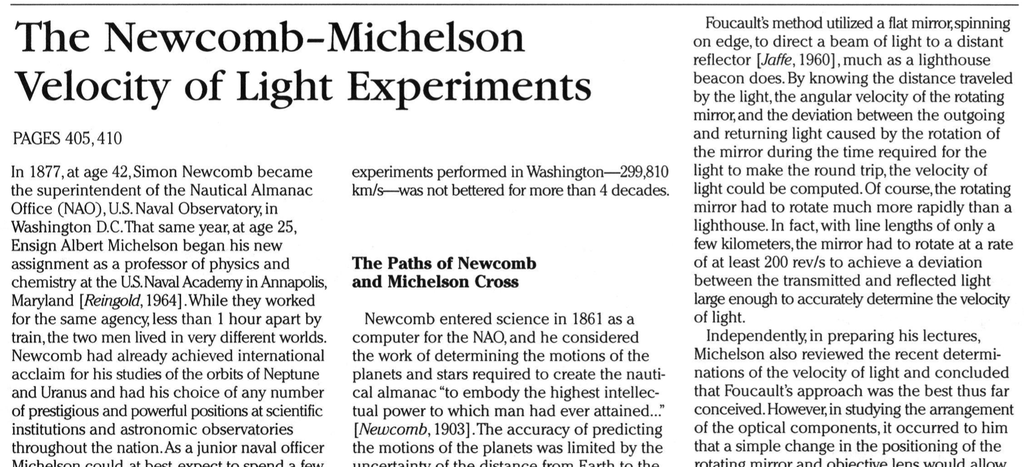

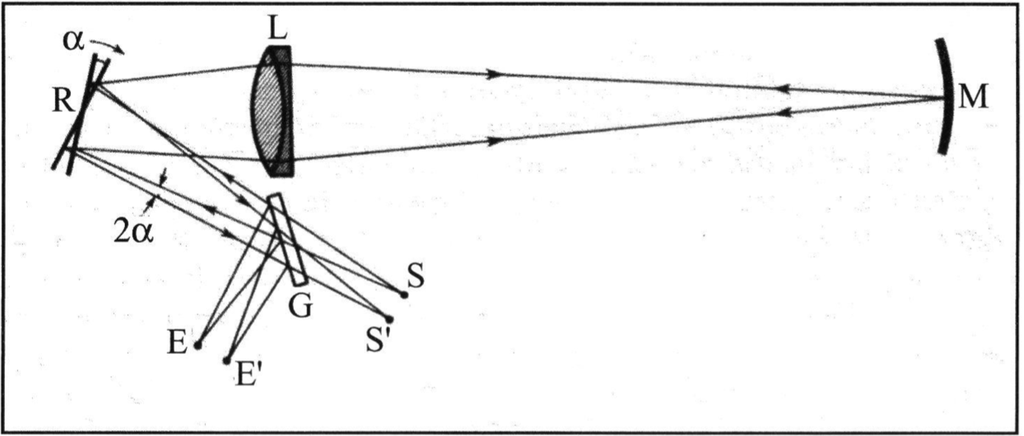

A light pulse travels a known total path length $d$. Its travel time is measured repeatedly.

The example contains **66 travel time measurements**.

Let $\mu>0$ be the true travel time. The corresponding speed is $c=d/\mu$.

Model the measurements as

$$X_i=\mu+\varepsilon_i,$$

where $\varepsilon_i$ is the measurement error.

## Two models for the measurement errors

STATISTICAL INFERENCE ● WEEK 6

For the travel time measurements $X_i=\mu+\varepsilon_i$, assume independent errors with the same distribution.

A parametric model

$$\varepsilon_i\sim N(0,\sigma^2).$$

The unknown parameters are $(\mu,\sigma^2)$, with $\mu>0$ and $\sigma^2>0$.

A nonparametric model

The error CDF $F$ is continuous and symmetric about zero:

$$F(u)=1-F(-u)\quad(u\in\mathbb R).$$

Both $\mu$ and $F$ are unknown.

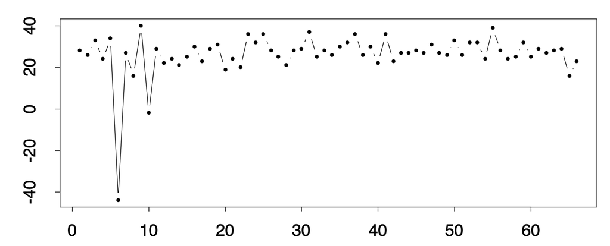

Horizontal axis: measurement number. Vertical axis: deviation from 24800 nanoseconds.

## Statistics

STATISTICAL INFERENCE ● WEEK 6

Definition 11.2

A measurable function $T$ of the sample that does not depend on unknown parameters is called a **statistic**. It may be vector valued.

For $n\ge2$, examples are
$$\overline X=\frac1n\sum_{i=1}^n X_i,\qquad
S^2=\frac1{n-1}\sum_{i=1}^n(X_i-\overline X)^2.$$

But $n^{-1}\sum_i(X_i-\mu)^2$ is **not** a statistic when $\mu$ is unknown.

One distinguishes the map $T$, the random value $T(X)$, and the observed value $T(x)$.

## Sampling distributions

STATISTICAL INFERENCE ● WEEK 6

Definition 11.3

Under a specified sampling model, the probability distribution of $T(X)$ is called its **sampling distribution**.

A Bernoulli sample

If $X_i\overset{\mathrm{iid}}\sim\operatorname{Bernoulli}(p)$, then

$$T=\sum_iX_i\sim\operatorname{Bin}(n,p).$$

The sample mean is $\overline X=T/n$.

A normal sample

If $X_i\overset{\mathrm{iid}}\sim N(\mu,\sigma^2)$, then

$$\overline X\sim N\!\left(\mu,\frac{\sigma^2}{n}\right).$$

This holds exactly for every $n$.

## Example: Modelling the orbit of Mars

STATISTICAL INFERENCE ● WEEK 6

[figure not shown]

## Example: A statistical model for Mars

STATISTICAL INFERENCE ● WEEK 6

At a known time $t_i$, let $Y_i$ denote the measured longitude of Mars.

An orbital model predicts the longitude $m_\theta(t_i)$. The unknown parameters $\theta$ describe quantities such as the orbital period and orientation.

Allow the measured position to differ from the prediction:

$$Y_i=m_\theta(t_i)+\varepsilon_i.$$

For example, assume $\varepsilon_i\overset{\mathrm{iid}}\sim N(0,\sigma^2)$.

Then the observations are independent normal variables with common variance, but their means $m_\theta(t_i)$ generally differ. Thus the observations need not be identically distributed.

## Observed positions and fitted residuals

STATISTICAL INFERENCE ● WEEK 6

Let $m(t_i)$ be a fitted prediction and $y_i$ a recorded position.

The **root mean square (RMS) residual** over the ten fitting observations is

$$\operatorname{RMS}=\sqrt{\frac1{10}\sum_{i=1}^{10}\bigl(y_i-m(t_i)\bigr)^2}.$$

[figure not shown]

Historical reduced data. Different vertical scales. Smaller residuals do not validate the error assumptions. Recorded values and fitted predictions

## Sufficient statistics

STATISTICAL INFERENCE ● WEEK 6

Definition 11.4

Let $X$ have distribution $P_\theta$ on $(\mathcal X,\mathcal A)$.

A statistic $T(X)$ is called **sufficient** if, for every $A\in\mathcal A$, there is a measurable function $q_A$, not depending on $\theta$, such that for every $\theta$,

$$\mathbb P_\theta(X\in A\mid T(X))=q_A(T(X))
\quad P_\theta\text{ almost surely}.$$

## Bernoulli model: Sufficiency

STATISTICAL INFERENCE ● WEEK 6

Let $X_i\overset{\mathrm{iid}}\sim\operatorname{Bernoulli}(p)$, $p\in(0,1)$, and $T=\sum_iX_i$.

For $t=0,\ldots,n$ and $x\in\{0,1\}^n$ with $\sum_ix_i=t$,
$$\mathbb P_p(X=x\mid T=t)
=\frac{p^t(1-p)^{n-t}}{\binom nt p^t(1-p)^{n-t}}
=\binom nt^{-1}.$$
It is zero for vectors with a different count.

Proposition 11.5

The total number of successes is sufficient for $p$. Conditional on the count, their arrangement is uniform and does not depend on $p$.

## The Neyman and Fisher factorization theorem

STATISTICAL INFERENCE ● WEEK 6

Theorem 11.6

Let $f_\theta$ be the joint probability mass function or joint density of the sample. The counting measure or Lebesgue measure used for it is the same for every parameter.

A statistic $T$ is sufficient if and only if there are nonnegative measurable functions $g_\theta$ and $h$ such that
$$f_\theta(x)=g_\theta(T(x))\,h(x)
\quad\text{for almost every }x,\text{ for every }\theta.$$
The factor $h$ does not depend on $\theta$. the other factor uses the sample only through $T(x)$.

## Factorization proof for a countable sample space

STATISTICAL INFERENCE ● WEEK 6

**From factorization to sufficiency.** Suppose $f_\theta(x)=g_\theta(T(x))h(x)$ and put
$$H(t)=\sum_{z:T(z)=t}h(z).$$
For $T(x)=t$ and $\mathbb P_\theta(T=t)>0$,
$$\mathbb P_\theta(X=x\mid T=t)
=\frac{g_\theta(t)h(x)}{g_\theta(t)H(t)}
=\frac{h(x)}{H(t)}.$$

**Conversely.** If $T$ is sufficient with common conditional pmf $k(x\mid t)$, take
$$g_\theta(t)=\mathbb P_\theta(T=t),\qquad h(x)=k(x\mid T(x)).$$
Then $f_\theta(x)=g_\theta(T(x))h(x)$.

## A density ratio characterisation

STATISTICAL INFERENCE ● WEEK 6

Proposition 11.7

Assume the sample densities $f_\theta$ have a common positive support. Let $q_\theta$ be sampling densities of $T$, with respect to one common measure.

Then $T$ is sufficient if and only if
$$\frac{f_\theta(x)}{q_\theta(T(x))}$$
does not depend on $\theta$, wherever the denominator is positive.

**Proof.** If the ratio is $r(x)$, then $f_\theta(x)=q_\theta(T(x))r(x)$ is a factorization.

Conversely, factorization and a fixed reference parameter $\theta_0$ give $f_\theta(x)=a_\theta(T(x))f_{\theta_0}(x)$. Integrating over $\{T\in B\}$ yields $q_\theta(t)=a_\theta(t)q_{\theta_0}(t)$, so the ratio is independent of $\theta$.

## Normal observations with known variance

STATISTICAL INFERENCE ● WEEK 6

Assume $X_i\overset{\mathrm{iid}}\sim N(\mu,\sigma_0^2)$ with known $\sigma_0^2>0$.

The identity
$$\sum_i(x_i-\mu)^2=\sum_i(x_i-\overline x)^2+n(\overline x-\mu)^2$$
follows by expansion and $\sum_i(x_i-\overline x)=0$.

It gives the factorization

$$f_\mu(x)=
\underbrace{(2\pi\sigma_0^2)^{-n/2}
\exp\!\left(-\frac{\sum_i(x_i-\overline x)^2}{2\sigma_0^2}\right)}_{h(x)}
\underbrace{\exp\!\left(-\frac{n(\overline x-\mu)^2}{2\sigma_0^2}\right)}_{g_\mu(\overline x)}.$$

Thus $\overline X$ is sufficient for $\mu$.

## Normal observations with both parameters unknown

STATISTICAL INFERENCE ● WEEK 6

Now $X_i\overset{\mathrm{iid}}\sim N(\mu,\sigma^2)$, with both parameters unknown. Put
$$s(x)=\sum_i x_i,\qquad q(x)=\sum_i x_i^2.$$
Then
$$f_{\mu,\sigma^2}(x)=(2\pi\sigma^2)^{-n/2}
\exp\!\left(-\frac{q(x)-2\mu s(x)+n\mu^2}{2\sigma^2}\right).$$

Proposition 11.8

$T(X)=(\sum_iX_i,\sum_iX_i^2)$ is sufficient for $(\mu,\sigma^2)$.

The coefficient of the spread is unknown: it can no longer be absorbed into a factor that does not depend on the parameter.

## A uniform sample with unknown endpoint

STATISTICAL INFERENCE ● WEEK 6

Let $X_i\overset{\mathrm{iid}}\sim U(0,\theta)$, $\theta>0$. Let $x_{(1)}=\min_i x_i$ and $x_{(n)}=\max_i x_i$.

The **whole** joint density is
$$f_\theta(x)=\theta^{-n}\,
\mathbf1_{\{x_{(1)}>0\}}\,
\mathbf1_{\{x_{(n)}<\theta\}}.$$
Factor it as
$$g_\theta(m)=\theta^{-n}\mathbf1_{\{m<\theta\}},\qquad
h(x)=\mathbf1_{\{x_{(1)}>0\}}.$$
Thus the sample maximum $M=X_{(n)}$ is sufficient for $\theta$.

## Order statistics: Sufficiency

STATISTICAL INFERENCE ● WEEK 6

Proposition 11.9

If $X_i$ are i.i.d. from an unknown density $f$, then the sorted vector
$$T(X)=(X_{(1)},\ldots,X_{(n)})$$
is sufficient for the density family.

**Proof.** For every candidate $f$,
$$f_X(x)=\prod_{i=1}^n f(x_i)=\prod_{i=1}^n f(x_{(i)}).$$
Apply factorization. The original order is discarded, but all $n$ values remain.

This argument does **not** justify sorting responses while forgetting their different observation times.

# Lecture 12

STATISTICAL INFERENCE ● WEEK 6

Week 6 · Minimality and completeness

The coarsest sufficient information. exponential structure. uniqueness from expectations.

## Minimal sufficient statistics

STATISTICAL INFERENCE ● WEEK 6

Definition 12.1

A sufficient statistic $T(X)$ is called **minimal sufficient** if, for every sufficient statistic $U(X)$, there is a measurable function $\varphi$ such that
$$T(X)=\varphi(U(X))
\quad P_\theta\text{ almost surely for every }\theta.$$
The function $\varphi$ may depend on $U$, but not on $\theta$.

Minimal sufficient statistics need not be unique. Measurable invertible transformations preserve the information retained.

## Criterion for minimal sufficiency

STATISTICAL INFERENCE ● WEEK 6

Let $f_\theta$ be the joint density or probability mass function of the sample under $P_\theta$.

Theorem 12.2

Let $T$ be sufficient. Suppose that, for all sample points $x,y$,
$$T(x)=T(y)
\quad\Longleftrightarrow\quad
f_\theta(x)=c(x,y)f_\theta(y)\text{ for every }\theta,$$
for some $c(x,y)>0$ independent of $\theta$.

Then $T$ is minimal sufficient.

If the support depends on $\theta$, the equality must also hold for parameter values at which one of the densities is zero.

## Bernoulli model: Minimal sufficiency

STATISTICAL INFERENCE ● WEEK 6

For $x,y\in\{0,1\}^n$, let $t_x=\sum_i x_i$ and $t_y=\sum_i y_i$.
$$\frac{f_p(x)}{f_p(y)}
=\left(\frac{p}{1-p}\right)^{t_x-t_y}.$$

- If $t_x=t_y$, the ratio is $1$.
- If $t_x\ne t_y$, the ratio varies as $p$ ranges over $(0,1)$.

Together with sufficiency, the criterion proves:

Proposition 12.3

For an i.i.d. Bernoulli$(p)$ sample, $\sum_iX_i$ is minimal sufficient. So is $\overline X$, because $n$ is known.

## Normal model: Minimal sufficiency

STATISTICAL INFERENCE ● WEEK 6

Write $s(x)=\sum_i x_i$ and $q(x)=\sum_i x_i^2$, and similarly for $y$. Then
$$\log\frac{f_{\mu,\sigma^2}(x)}{f_{\mu,\sigma^2}(y)}
=\frac{\mu(s(x)-s(y))}{\sigma^2}-\frac{q(x)-q(y)}{2\sigma^2}.$$

**Known variance.** The ratio is constant in $\mu\in\mathbb R$ exactly when $s(x)=s(y)$. Thus $\overline X$ is minimal sufficient.

**Both parameters unknown.** Varying $\mu$ forces $s(x)=s(y)$. Varying $\sigma^2>0$ then forces $q(x)=q(y)$. Conversely, if both equalities hold, the density ratio equals $1$ for every parameter value.

Hence $(\sum_iX_i,\sum_iX_i^2)$ is minimal sufficient for $(\mu,\sigma^2)$.

## Normal model: Equivalent statistics

STATISTICAL INFERENCE ● WEEK 6

For a normal sample of size $n\ge2$, define the sample variance by
$$S^2=\frac{1}{n-1}\sum_{i=1}^n(X_i-\overline X)^2.$$

The statistics $(\sum_iX_i,\sum_iX_i^2)$ and $(\overline X,S^2)$ determine one another:
$$\overline X=\frac{\sum_iX_i}{n},\qquad
S^2=\frac{\sum_iX_i^2-(\sum_iX_i)^2/n}{n-1},$$
$$\sum_iX_i=n\overline X,\qquad
\sum_iX_i^2=(n-1)S^2+n\overline X^2.$$

Proposition 12.4

A measurable one to one transformation with measurable inverse preserves sufficiency and minimal sufficiency.

## Uniform model: Minimal sufficiency

STATISTICAL INFERENCE ● WEEK 6

For a positive sample vector $x$, the joint density is
$$f_\theta(x)=\theta^{-n}\mathbf1_{\{\theta>x_{(n)}\}}.$$

- If $x_{(n)}=y_{(n)}$, then $f_\theta(x)=f_\theta(y)$ for every $\theta$.
- If $x_{(n)}<y_{(n)}$, choose $x_{(n)}<\theta<y_{(n)}$. Then $f_\theta(x)>0$ but $f_\theta(y)=0$.

Thus the proportionality condition in Theorem 12.2 holds exactly when $x_{(n)}=y_{(n)}$.

Proposition 12.5

For an i.i.d. $U(0,\theta)$ sample, $X_{(n)}$ is minimal sufficient for $\theta$.

## Exponential families

STATISTICAL INFERENCE ● WEEK 6

Definition 12.6

A family whose support does not depend on $\theta$ is called an **exponential family** if, for some integer $k\ge1$, its densities can be written as
$$f(x\mid\theta)=h(x)c(\theta)
\exp\!\left(\sum_{j=1}^k w_j(\theta)t_j(x)\right),$$
where $c(\theta)>0$, $h(x)\ge0$, each $w_j,t_j$ takes values in $\mathbb R$, and each $t_j$ is measurable.

The functions $h$ and $t=(t_1,\ldots,t_k)$ do not involve $\theta$. The common support is $\{x:h(x)>0\}$.

Here $x$ denotes one observation. The coefficients $w_j(\theta)$ are called **natural parameters**. Write $w=(w_1,\ldots,w_k)$.

For i.i.d. $X_1,\ldots,X_n$, the statistic $T_n=\sum_{i=1}^n t(X_i)$ is called the **canonical statistic**.

## Examples of exponential families: Binomial

STATISTICAL INFERENCE ● WEEK 6

Let $Y\sim\operatorname{Bin}(m,p)$, where $m$ is known and $p\in(0,1)$. For $y=0,\ldots,m$,
$$f(y\mid p)
=\binom my p^y(1-p)^{m-y}
=\underbrace{\binom my}_{h(y)}\,
\underbrace{(1-p)^m}_{c(p)}\,
\exp\!\left(\underbrace{\log\frac{p}{1-p}}_{w(p)}\,
\underbrace{y}_{t(y)}\right).$$

The natural parameter is $\eta=\log[p/(1-p)]\in\mathbb R$.

$$p=\frac{e^\eta}{1+e^\eta},\qquad
c(p)=(1+e^\eta)^{-m}.$$

For an i.i.d. sample $X_i\sim\operatorname{Bin}(m,p)$, the canonical statistic is $T_n=\sum_iX_i$.

## Examples of exponential families: Normal

STATISTICAL INFERENCE ● WEEK 6

For a single $N(\mu,\sigma^2)$ observation,
$$f(x\mid\mu,\sigma^2)
=\underbrace{(2\pi\sigma^2)^{-1/2}e^{-\mu^2/(2\sigma^2)}}_{c(\mu,\sigma^2)}
\exp\!\left(\frac{\mu}{\sigma^2}x-\frac{1}{2\sigma^2}x^2\right).$$

One choice is $h(x)=1$ and
$$t_1(x)=x,\quad t_2(x)=x^2,\qquad
w_1=\frac{\mu}{\sigma^2},\quad w_2=-\frac1{2\sigma^2}.$$

The two natural coordinates range over $\mathbb R\times(-\infty,0)$ when both normal parameters are free. For an i.i.d. sample, the canonical statistic is $T_n=(\sum_iX_i,\sum_iX_i^2)$.

## Natural parameter spaces

STATISTICAL INFERENCE ● WEEK 6

Definition 12.7

For fixed $h$ and $t=(t_1,\ldots,t_k)$, define
$$Z(\eta)=\int_{\mathcal X}h(x)e^{\eta\cdot t(x)}\,d\nu(x),\qquad
\mathcal N=\{\eta\in\mathbb R^k:0<Z(\eta)<\infty\}.$$
The set $\mathcal N$ is called the **natural parameter space**. Here $\nu$ is counting measure or Lebesgue measure. For $\eta\in\mathcal N$, put $A(\eta)=\log Z(\eta)$.

| Distribution of each $X_i$ (i.i.d.) | Canonical statistic $T_n$ | Natural parameter $\eta$ | Natural parameter space $\mathcal N$ |
| --- | --- | --- | --- |
| $\operatorname{Bin}(m,p)$, fixed $m\ge1$, $0<p<1$ | $\sum_iX_i$ | $\log[p/(1-p)]$ | $\mathbb R$ |
| $\operatorname{Pois}(\lambda)$, $\lambda>0$ | $\sum_iX_i$ | $\log\lambda$ | $\mathbb R$ |
| Exponential with rate $\lambda>0$ | $\sum_iX_i$ | $-\lambda$ | $(-\infty,0)$ |
| $N(\mu,\sigma^2)$, both unknown | $(\sum_iX_i,\sum_iX_i^2)$ | $(\mu/\sigma^2,-1/(2\sigma^2))$ | $\mathbb R\times(-\infty,0)$ |

The allowed parameter set is $\Omega=w(\Theta)\subseteq\mathcal N$. A family is called **full** if $\Omega=\mathcal N$. It is called **curved** if $\Omega$ is a smooth set of dimension less than $k$.

## Sufficiency in exponential families

STATISTICAL INFERENCE ● WEEK 6

Theorem 12.8

Let $X_1,\ldots,X_n$ be i.i.d. with density or probability mass function
$$f(x\mid\theta)=h(x)c(\theta)
\exp\!\left(\sum_{j=1}^k w_j(\theta)t_j(x)\right),$$
where $h,t_1,\ldots,t_k$ do not depend on $\theta$. Write $t=(t_1,\ldots,t_k)$. Then the canonical statistic $T_n=\sum_{i=1}^n t(X_i)$ is sufficient for $\theta$.

**Proof.** The joint density is
$$f_\theta(x)=\left(\prod_{i=1}^n h(x_i)\right)
c(\theta)^n\exp\!\left(\sum_{j=1}^k w_j(\theta)\sum_{i=1}^n t_j(x_i)\right).$$
The first factor is independent of $\theta$, so Theorem 11.6 applies.

## Completeness

STATISTICAL INFERENCE ● WEEK 6

Definition 12.9

A statistic $T$ is called **complete** if every measurable $a$ satisfying $\mathbb E_\theta(|a(T)|)<\infty$ for every $\theta$ obeys
$$\mathbb E_\theta(a(T))=0\ \text{for every }\theta
\quad\Longrightarrow\quad
\mathbb P_\theta(a(T)=0)=1\ \text{for every }\theta.$$

## Bernoulli model: Completeness

STATISTICAL INFERENCE ● WEEK 6

Let $T\sim\operatorname{Bin}(n,p)$ with $p\in(0,1)$. Suppose
$$0=\mathbb E_p(a(T))
=\sum_{t=0}^n a(t)\binom nt p^t(1-p)^{n-t}
\quad\text{for every }p.$$
Divide by the positive factor $(1-p)^n$ and set $z=p/(1-p)$:
$$\sum_{t=0}^n a(t)\binom nt z^t=0\qquad\text{for every }z>0.$$
A polynomial vanishing on $(0,\infty)$ has every coefficient zero. Since $\binom nt>0$, all $a(t)=0$.

Therefore the Bernoulli count is **complete and sufficient**.

## Completeness in exponential families

STATISTICAL INFERENCE ● WEEK 6

Theorem 12.10

For an exponential family, let $\Omega=w(\Theta)\subseteq\mathcal N$ be the set of natural parameter values used by the model.

If $\Omega$ contains a nonempty open rectangle in $\mathbb R^k$, then the canonical statistic
$$T_n=\sum_{i=1}^n t(X_i)$$
of an i.i.d. sample is complete and sufficient.

For the normal model with both parameters unknown, $\Omega=\mathcal N=\mathbb R\times(-\infty,0)$. Thus $(\sum_iX_i,\sum_iX_i^2)$ is complete and sufficient.

A curved family has no such rectangle in $\Omega$. This theorem does not decide completeness in that case.

## Complete sufficient statistics

STATISTICAL INFERENCE ● WEEK 6

Theorem 12.11

Suppose the model admits a minimal sufficient statistic. Then every statistic that is **complete and sufficient** is minimal sufficient.

Completeness alone is not enough. In the Bernoulli model, $T\equiv0$ is complete but not sufficient, since
$$\mathbb P_p(X_1=1\mid T=0)=p.$$

Completeness will give uniqueness in estimation. If two integrable functions of $T$ have the same expectation for every parameter, their difference has expectation zero, so they agree almost surely.

## Mars example: Sufficiency

STATISTICAL INFERENCE ● WEEK 6

For the Mars longitudes, assume $Y_i=\alpha+bt_i+\varepsilon_i$, with fixed known times $t_i$ and independent $N(0,\sigma^2)$ errors. Here $\alpha$ is the initial longitude and $b$ the constant angular speed. Longitudes include completed revolutions.

$$\begin{aligned}
f_{\alpha,b,\sigma^2}(y)
={}&\underbrace{(2\pi\sigma^2)^{-n/2}
\exp\!\left(-\frac{n\alpha^2+2\alpha b\sum_i t_i+b^2\sum_i t_i^2}{2\sigma^2}\right)}_{\text{independent of }y}\\
&\quad\times\exp\!\left(-\frac{\sum_i y_i^2}{2\sigma^2}
+\frac{\alpha}{\sigma^2}\sum_i y_i
+\frac{b}{\sigma^2}\sum_i t_i y_i\right).
\end{aligned}$$

The sums $\sum_i t_i$ and $\sum_i t_i^2$ are known constants, so they need not be included in the statistic.

In the factorization $f_\theta(y)=h(y)g_\theta(T(y))$ from Theorem 11.6, we can choose:

| Variance | $h(y)$ | Sufficient statistic $T(Y)$ |
| --- | --- | --- |
| $\sigma^2$ known | $\exp[-\sum_i y_i^2/(2\sigma^2)]$ | $(\sum_iY_i,\sum_i t_iY_i)$ |
| $\sigma^2$ unknown | $1$ | $(\sum_iY_i,\sum_i t_iY_i,\sum_iY_i^2)$ |

If $\sigma^2$ is unknown, we additionally retain $\sum_iY_i^2$ because its coefficient is unknown.